# Bridge condition prediction

An exploration in Linear Models

Authors

Gonçalo Duarte

Joana Ferreira

Lucas Pegas

Published

December 22, 2025

# 1 Introduction

$$\b{y} \sim N_n \left(\b{X} \bs{\beta}, \sigma^2\b{I}\right)$$

For this project we’ll evaluate a dataset extracted from the US National Bridge Inspection maintained by the Federal Highways Agency, part of the US Department of Transportation.

Our goals is to analyse how the covariates can explain the bridge condition and propose one or more linear rgression models to predict the response variable for the `predict.csv` dataset.

## 1.1 Data Set Overview

| Variable | Description |
| --- | --- |
| Structure_id | Identification key |
| Urban | Whether the bridge is in an urban or rural area |
| Year | The year the bridge was built |
| Lanes_on | Number of traffic lanes on the bridge |
| AverageDaily | The average daily traffic (number of vehicles) |
| Historic | Whether the bridge is historic |
| Material | The dominant material the bridge is made from |
| Spans | Number of spans of the bridge |
| Length | The length of the bridge (m) |
| Width | The width of the bridge (m) |
| Trucks_percent | The percentage of traffic made up of trucks |

# 2 Exploratory data analysis

Here’s the summary of the dataset.

```r
group_03 <- read.csv("group_03.csv")


group_03$Urban <- as.factor(group_03$Urban)
group_03$Historic <- as.factor(group_03$Historic)
group_03$Material <- as.factor(group_03$Material)

summary(group_03)
```

```
 Structure_id         Urban            Year         Lanes_on
 Length:29886       Rural:16157   Min.   :1900   Min.   : 1.000
 Class :character   Urban:13729   1st Qu.:1964   1st Qu.: 2.000
 Mode  :character                 Median :1985   Median : 2.000
                                  Mean   :1981   Mean   : 2.387
                                  3rd Qu.:2002   3rd Qu.: 2.000
                                  Max.   :2019   Max.   :15.000
  AverageDaily              Historic         Material         Spans
 Min.   :     0.0   Not historic:17344   Concrete:23611   Min.   :  0.000
 1st Qu.:   328.5   Possible    :12132   Masonry :   13   1st Qu.:  1.000
 Median :  3270.0   Register    :  362   Other   :   45   Median :  3.000
 Mean   : 11639.4   Unknown     :   48   Steel   : 5807   Mean   :  3.774
 3rd Qu.: 11850.0                        Timber  :  410   3rd Qu.:  4.000
 Max.   :543000.0                                         Max.   :194.000
     Length            Width        Trucks_percent     Condition
 Min.   :   6.10   Min.   :  2.50   Min.   : 0.000   Min.   : 0.00
 1st Qu.:  24.40   1st Qu.:  7.30   1st Qu.: 0.000   1st Qu.:19.00
 Median :  47.70   Median : 10.90   Median : 5.000   Median :21.00
 Mean   :  93.22   Mean   : 11.79   Mean   : 8.567   Mean   :20.29
 3rd Qu.:  87.80   3rd Qu.: 13.40   3rd Qu.:13.000   3rd Qu.:22.00
 Max.   :6270.30   Max.   :228.00   Max.   :99.000   Max.   :27.00
```

### 2.0.1 Response variable

Now lets take a look at the response variable to understand how it is distributed.

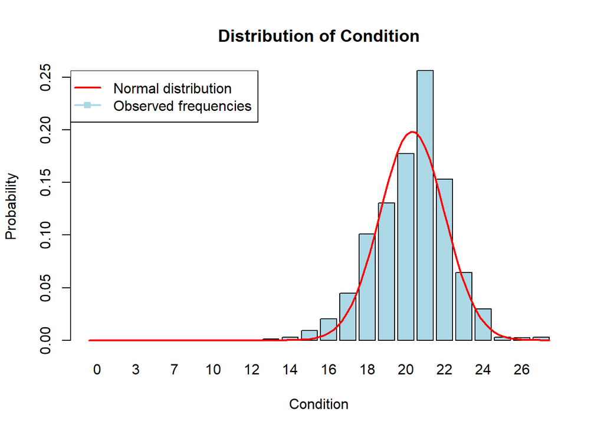

Response variable distribution

```r
# Basic histogram with normal curve overlay
freq_table <- table(group_03$Condition)
prob_table <- prop.table(freq_table)

# Barplot with normal overlay
barplot(prob_table,
        main = "Distribution of Condition",
        xlab = "Condition",
        ylab = "Probability",
        col = "lightblue",
        border = "black")

# Add normal curve overlay
x_vals <- as.numeric(names(prob_table))
curve(dnorm(x, mean = mean(group_03$Condition),
            sd = sd(group_03$Condition)),
      col = "red",
      lwd = 2,
      add = TRUE)

legend("topleft",
       legend = c("Normal distribution", "Observed frequencies"),
       col = c("red", "lightblue"),
       lwd = 2,
       pch = c(NA, 15))
```

```r
library(moments);
skewness(group_03$Condition)
```

```
[1] -0.7822186
```

A skewness value of -0.78 confirms mild negative skewness, meaning the response distribution is moderately skewed towards the left. The deviation is not significant and as such the response variable should be compatible with linear with linear regression as long as residuals are well-behaved.

### 2.0.2 Numerical variables

Here we inspect the relationship between the numerical covariates and the bridge condition.

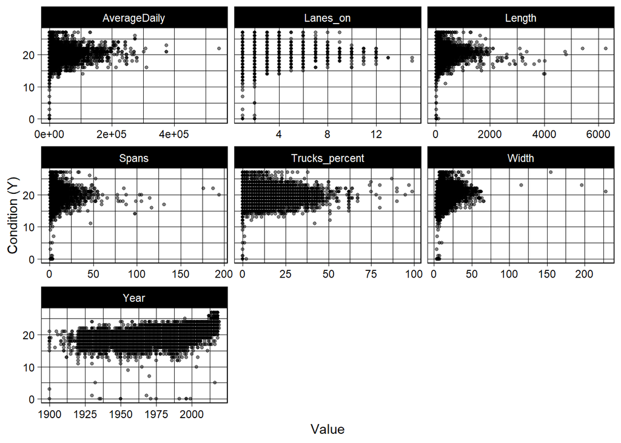

Numerical variables vs Condition

```r
db_num <- group_03 |>
  dplyr::select(Year, Lanes_on, AverageDaily, Spans, Length, Width, Trucks_percent, Condition)

# scatterplots
db_num |>
  pivot_longer(-Condition, names_to = "Covariate", values_to = "Value") |>
  ggplot(aes(x = Value, y = Condition)) +
  geom_point(alpha = 0.5, size = 1) +
  facet_wrap(~ Covariate, scales = "free_x") +
  theme_linedraw() +
  labs(y = "Condition (Y)", x = "Value")
```

From the scatter plots analysis, we can interpret the relationship between each numerical covariate and the bridge condition. Surprisingly, traffic and usage variables like `AverageDaily` and `Trucks_percent` do not show a strong correlation with the condition, suggesting that traffic volume alone is not a strong predictor. Similarly, physical dimensions such as `Lanes_on` and `Width` display no clear linear relationship, with data appearing heavily clustered. While `Length` and `Spans` exhibit a very weak downward trend, hinting that larger structures might be slightly associated with lower conditions, the pattern is inconclusive. In contrast, the `Year` variable presents the clearest relationship in the entire set, revealing a distinct positive trend where newer bridges tend to have higher condition scores, whereas older bridges (particularly pre-1950) display more low-condition outliers. Therefore, visual inspection strongly suggests that `Year` is the best single candidate for our initial linear model, being the only variable with a distinct linear trend against the response variable.

### 2.0.3 Pairwise correlation

Now we’ll go over the correlations with the response variable for all the numerical variables.

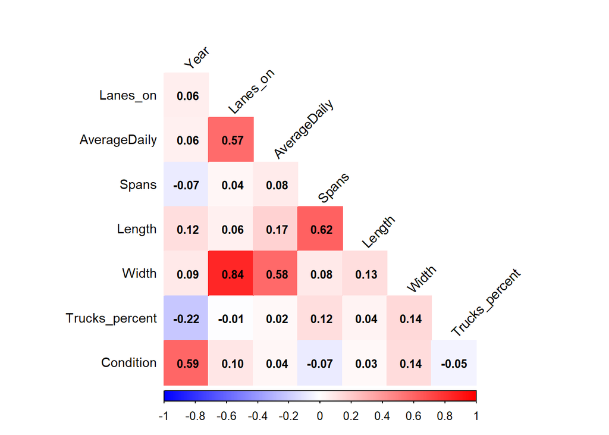

Pairwise correlation with the response variable.

```r
library(corrplot)
cor_matrix <- cor(group_03[, sapply(group_03, is.numeric)])

corrplot(cor_matrix, method = "color", type = "lower",
         addCoef.col = "black", number.cex = 0.8,
         tl.col = "black", tl.srt = 45, tl.cex = 0.9,
         col = colorRampPalette(c("blue", "white", "red"))(200),
         diag = FALSE)
```

Looking at the correlations with the response variable, `Condition`, we can see that the bridge’s `Year` has a significant positive correlation with its condition, indicating older bridges are in a worse condition. We can also see that variables `Width` and `Lanes_on` are positively correlated which makes sense as more lanes require more width. The average daily traffic is also positively correlated with the bridge width and number of lanes. Apart from this relation we can also see a negative correlation between the `Year` and `Trucks_percent` meaning that older bridges tend to have more truck traffic. This also seems plausible as newer bridges might be built in areas with more commuter trafic.

### 2.0.4 Categorical variables

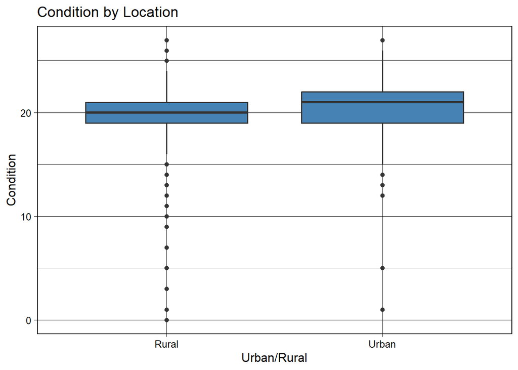

Categorical variables

```r
# For Urban
ggplot(group_03, aes(x = Urban, y = Condition)) +
  geom_boxplot(fill = "steelblue") +
  labs(title = "Condition by Location", x = "Urban/Rural", y = "Condition")
```

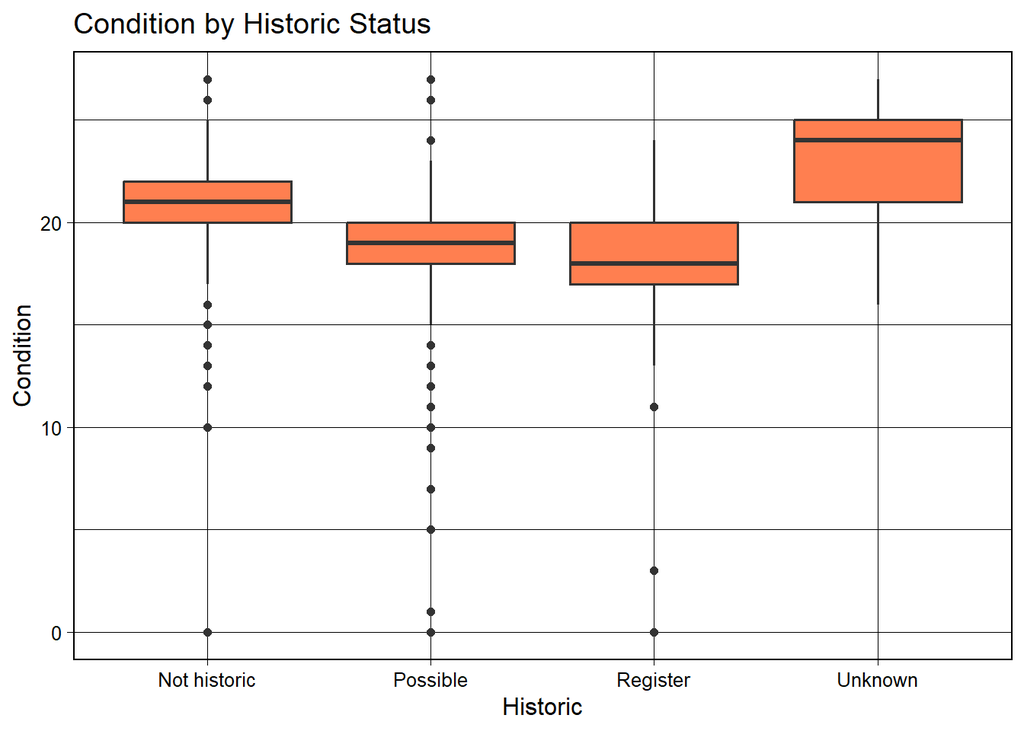

Categorical variables

```r
# For Historic
ggplot(group_03, aes(x = factor(Historic), y = Condition)) +
  geom_boxplot(fill = "coral") +
  labs(title = "Condition by Historic Status",
       x = "Historic", y = "Condition")
```

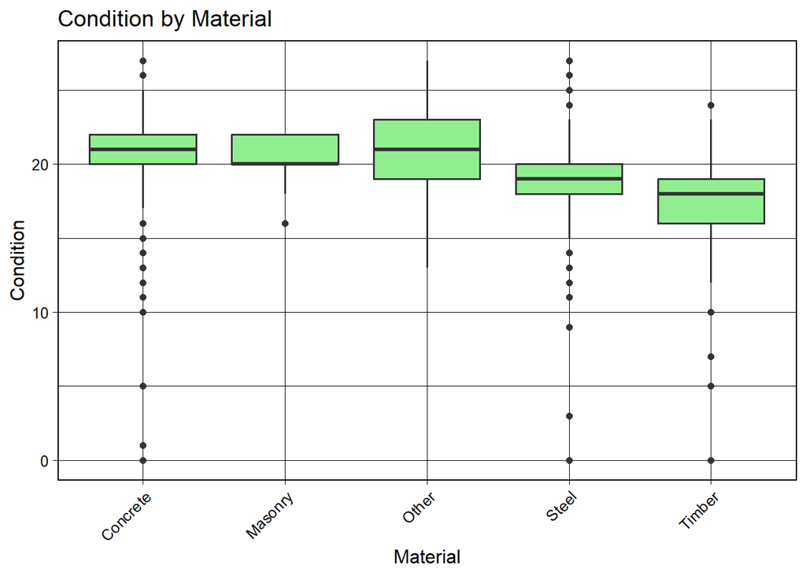

Categorical variables

```r
# For Material
ggplot(group_03, aes(x = factor(Material), y = Condition)) +
  geom_boxplot(fill = "lightgreen") +
  labs(title = "Condition by Material", x = "Material", y = "Condition") +
  theme(axis.text.x = element_text(angle = 45, hjust = 1))
```

When it comes to Historic Status we can see that Unknown shows the higher median, altough is the least common category. The `Not Historic`category also shows a high condition score with less variance than the bridges marked as `Possible`. The bridges registered as historic show the lowest median condition score with some highly degraded bridges. These scores indicate that historical status might be an informative categorical predictor.

The `Condition by Material Plot` shows a similar pattern. All the materials have a median condition measure close to 20 with Concrete and “Other” displaying a slightly higher median and Steel and Timber slightly below Timber.

### 2.0.5 Multivariate Analysis

Finally, let’s combine our findings. We know `Year` is the strongest numerical predictor and `Material` showed differences in the boxplots. This plot visualizes how they interact.

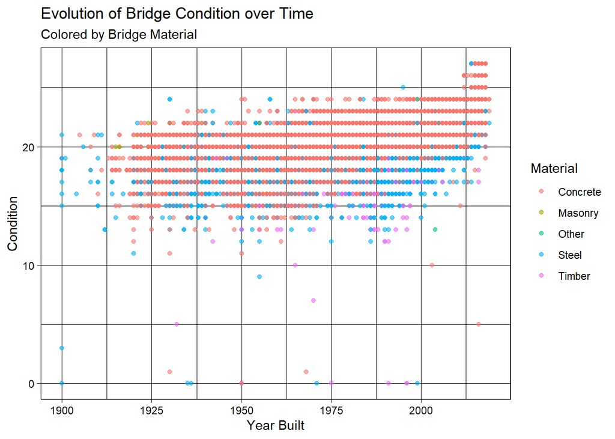

Evolution of Bridge Condition over Time colored by Material

```r
ggplot(group_03, aes(x = Year, y = Condition, color = Material)) +
  geom_point(alpha = 0.6) +
  labs(title = "Evolution of Bridge Condition over Time",
       subtitle = "Colored by Bridge Material",
       y = "Condition", x = "Year Built") +
  theme_linedraw()
```

## 2.1 The specification of linear models

Lets start by defining the most basic implementation of the model, that is, including all the covariates while excluding the structure_id.

```r
set.seed(3185)
n <- nrow(group_03)
train_idx <- sample(n, 0.8 * n)
db_train <- group_03[train_idx, ]
db_test  <- group_03[-train_idx, ]


model1 <- lm(Condition ~ . - Structure_id + Year:Material, data = db_train)
summary(model1)
```

```
Call:
lm(formula = Condition ~ . - Structure_id + Year:Material, data = db_train)

Residuals:
     Min       1Q   Median       3Q      Max
-19.7203  -0.8256   0.0572   0.8847   6.7619

Coefficients:
                       Estimate Std. Error t value Pr(>|t|)
(Intercept)          -9.038e+01  1.575e+00 -57.378  < 2e-16 ***
UrbanUrban           -6.303e-02  2.247e-02  -2.805  0.00503 **
Year                  5.597e-02  7.890e-04  70.947  < 2e-16 ***
Lanes_on             -3.230e-02  1.483e-02  -2.179  0.02938 *
AverageDaily         -2.137e-06  5.144e-07  -4.154 3.27e-05 ***
HistoricPossible      2.796e-01  3.638e-02   7.687 1.57e-14 ***
HistoricRegister      1.659e-01  9.956e-02   1.666  0.09574 .
HistoricUnknown       1.513e+00  2.393e-01   6.322 2.63e-10 ***
MaterialMasonry       5.053e+01  4.141e+01   1.220  0.22242
MaterialOther        -7.132e+00  1.913e+01  -0.373  0.70922
MaterialSteel         3.051e+01  1.975e+00  15.447  < 2e-16 ***
MaterialTimber       -1.491e+01  9.408e+00  -1.585  0.11292
Spans                -3.715e-02  2.574e-03 -14.432  < 2e-16 ***
Length                3.365e-04  7.011e-05   4.800 1.60e-06 ***
Width                 1.515e-02  2.839e-03   5.339 9.43e-08 ***
Trucks_percent        2.189e-03  1.041e-03   2.103  0.03548 *
Year:MaterialMasonry -2.506e-02  2.140e-02  -1.171  0.24172
Year:MaterialOther    3.448e-03  9.603e-03   0.359  0.71959
Year:MaterialSteel   -1.613e-02  9.985e-04 -16.155  < 2e-16 ***
Year:MaterialTimber   5.958e-03  4.744e-03   1.256  0.20914
---
Signif. codes:  0 '***' 0.001 '**' 0.01 '*' 0.05 '.' 0.1 ' ' 1

Residual standard error: 1.47 on 23888 degrees of freedom
Multiple R-squared:  0.4676,    Adjusted R-squared:  0.4672
F-statistic:  1104 on 19 and 23888 DF,  p-value: < 2.2e-16
```

Now lets examine the residuals.

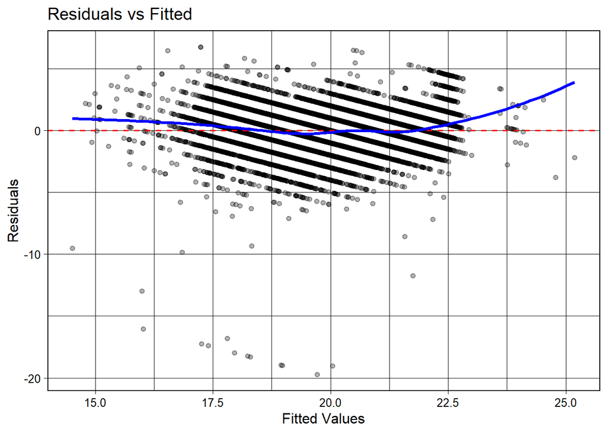

```r
ggplot(data.frame(fitted = fitted(model1), residuals = residuals(model1)),
       aes(x = fitted, y = residuals)) +
  geom_point(alpha = 0.3) +
  geom_hline(yintercept = 0, linetype = "dashed", color = "red") +
  geom_smooth(method = "loess", se = FALSE, color = "blue") +
  labs(x = "Fitted Values", y = "Residuals", title = "Residuals vs Fitted")
```

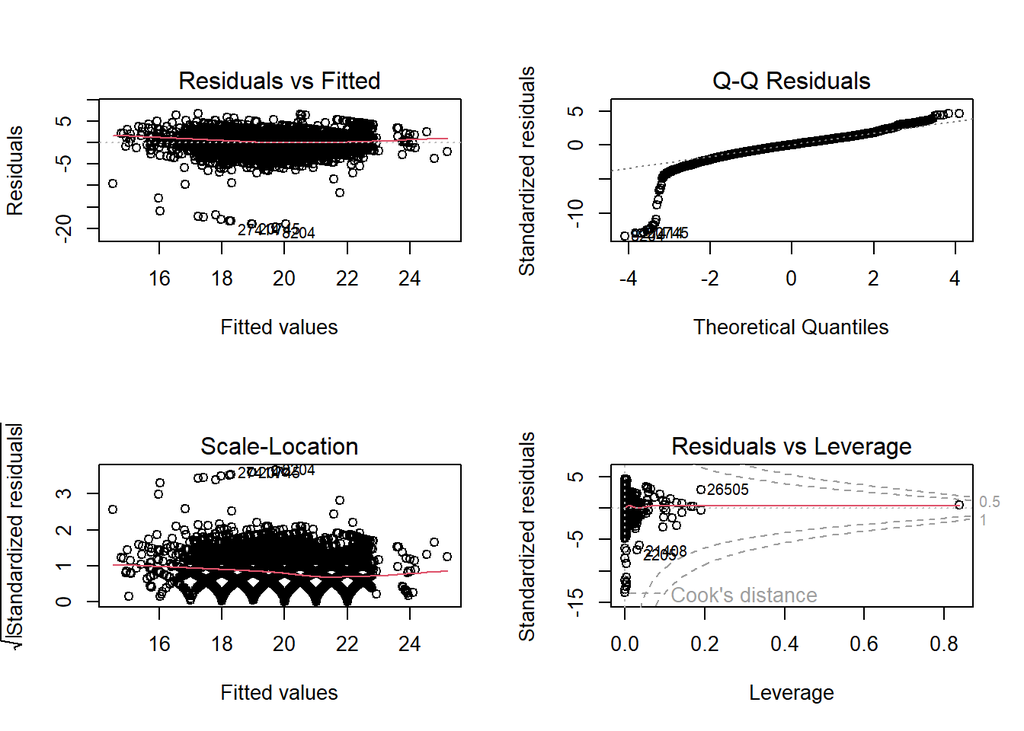

```r
par(mfrow=c(2,2))
plot(model1)
```

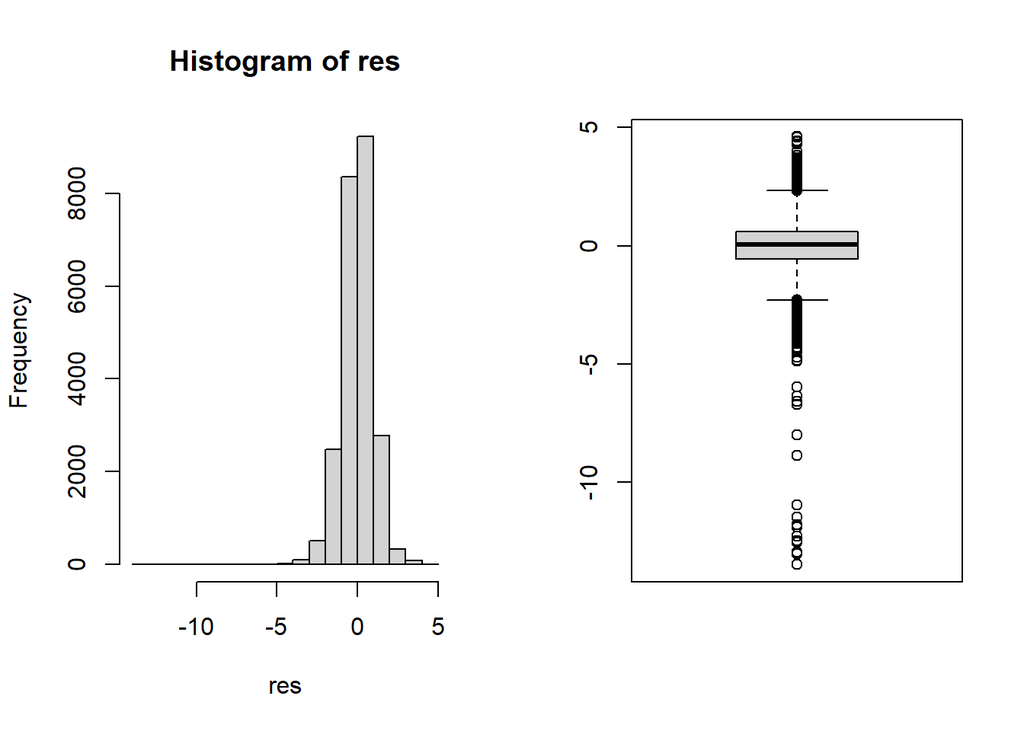

```r
par(mfrow=c(1,2))

res <- rstudent(model1)
hist(res)
boxplot(res)
```

## 2.2 Multicollinearity (VIF) test

```r
library(car)
vif(model1)
```

```
there are higher-order terms (interactions) in this model
consider setting type = 'predictor'; see ?vif
```

```
                       GVIF Df GVIF^(1/(2*Df))
Urban          1.386477e+00  1        1.177488
Year           3.925056e+00  1        1.981175
Lanes_on       3.679405e+00  1        1.918178
AverageDaily   1.730049e+00  1        1.315313
Historic       3.825625e+00  3        1.250596
Material       4.285376e+15  4       89.949471
Spans          1.765775e+00  1        1.328825
Length         1.876754e+00  1        1.369947
Width          3.888150e+00  1        1.971839
Trucks_percent 1.279380e+00  1        1.131097
Year:Material  4.285800e+15  4       89.950585
```

The Variance Inflation Factor (VIF) analysis reveals that there is no severe multicollinearity among the numerical predictors. Variables such as `Lanes_on` (3.68), `Width` (3.89), and `Year` (3.92) all display VIF values well below the standard thresholds of 5 or 10, justifying their retention in the model. While extremely high VIF values were observed for `Material` and the `Year`:`Material` interaction term (values around $4.28 \times 10^{15}$), this is an expected result known as structural multicollinearity. This phenomenon arises because the interaction term is mathematically dependent on the main effects, and as such, it does not indicate a statistical redundancy that requires the removal of variables.

## 2.3 Homocedasticity test

Using the Breusch-Pagan test:

```r
library(lmtest)
lmtest::bptest(model1)
```

```
    studentized Breusch-Pagan test

data:  model1
BP = 457.49, df = 19, p-value < 2.2e-16
```

Regarding the assumption of homoscedasticity, the Breusch-Pagan test yielded a p-value significantly lower than 0.05 ($p < 2.2e-16$), leading to the strong rejection of the null hypothesis. This result confirms the presence of severe heteroscedasticity, indicating that the variance of the residuals is not constant across the range of fitted values. The violation of this assumption implies that the standard errors—and consequently the significance tests—may not be entirely reliable. To address this issue and attempt to stabilize the variance, the next logical step in our analysis is to explore a transformation of the response variable using the Box-Cox method.

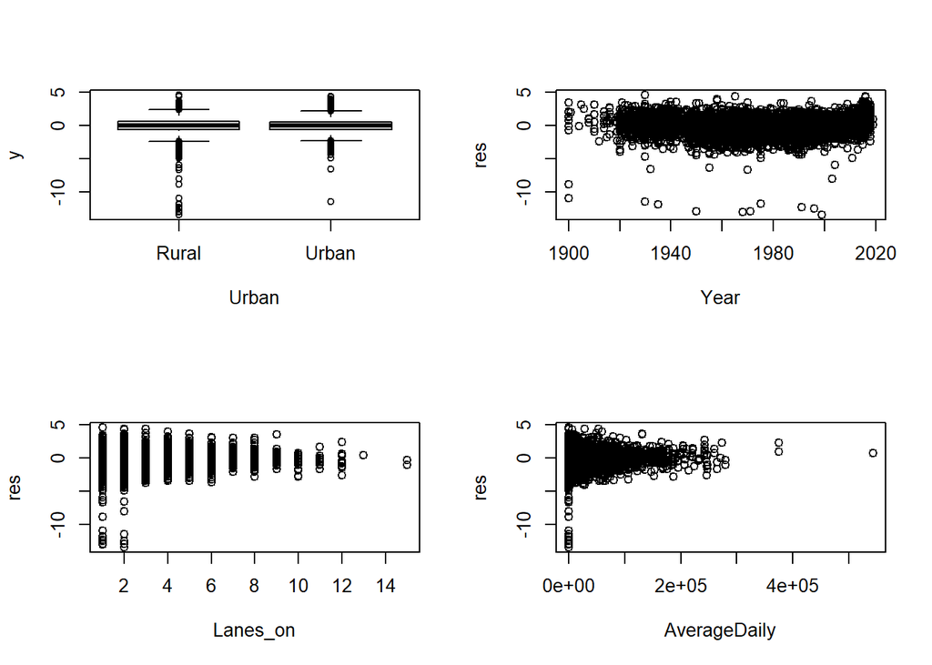

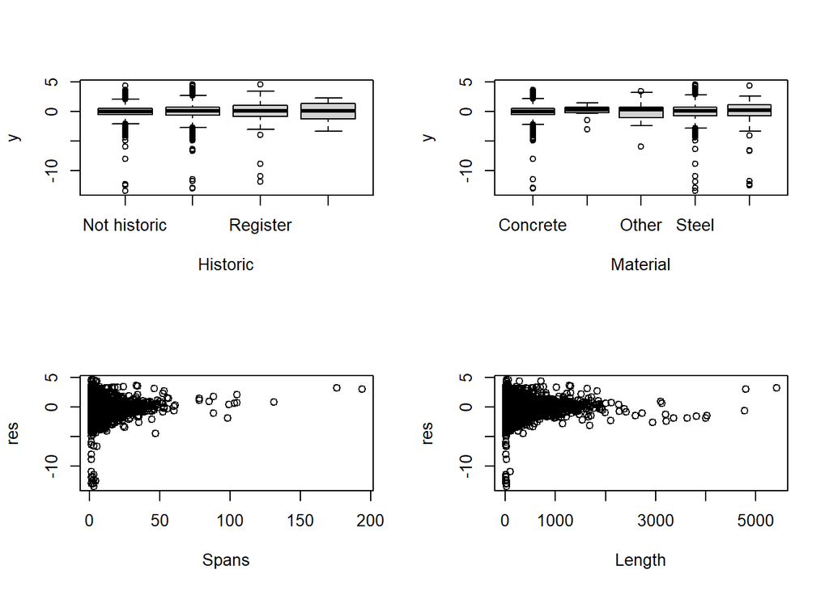

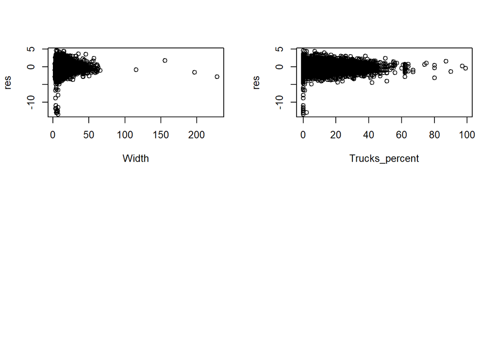

```r
par(mfrow=c(2,2))

vars <- names(db_train)
vars <- vars[!(vars %in% c("Structure_id", "Condition"))]

for(v in vars) plot(db_train[, v], res, xlab = v)
```

After observing the residuals vs covariates plots, we can conclude that while the box-plots for `Rural` and `Urban` appear to have similar distributions, this variable has become statistically significant in the interaction model, suggesting a subtle real effect. The plot of `residuals` vs `Year` shows a slight curve towards recent years, which supports the curvature presented in the `Residuals` vs `Fitted` plot and identifies `Year` as a potential source of our linearity problems. Furthermore, the box-plots for `Material` reveal differences in variance, particularly with `Timber` bridges displaying more negative residuals, while the remaining plots for numerical variables present a slight funnel shape; this indicates that variance shrinks or expands as covariate values grow, which reinforces the strong rejection of the null hypothesis in the Breusch-Pagan test regarding heteroscedasticity.

## 2.4 Box-Cox Transformation

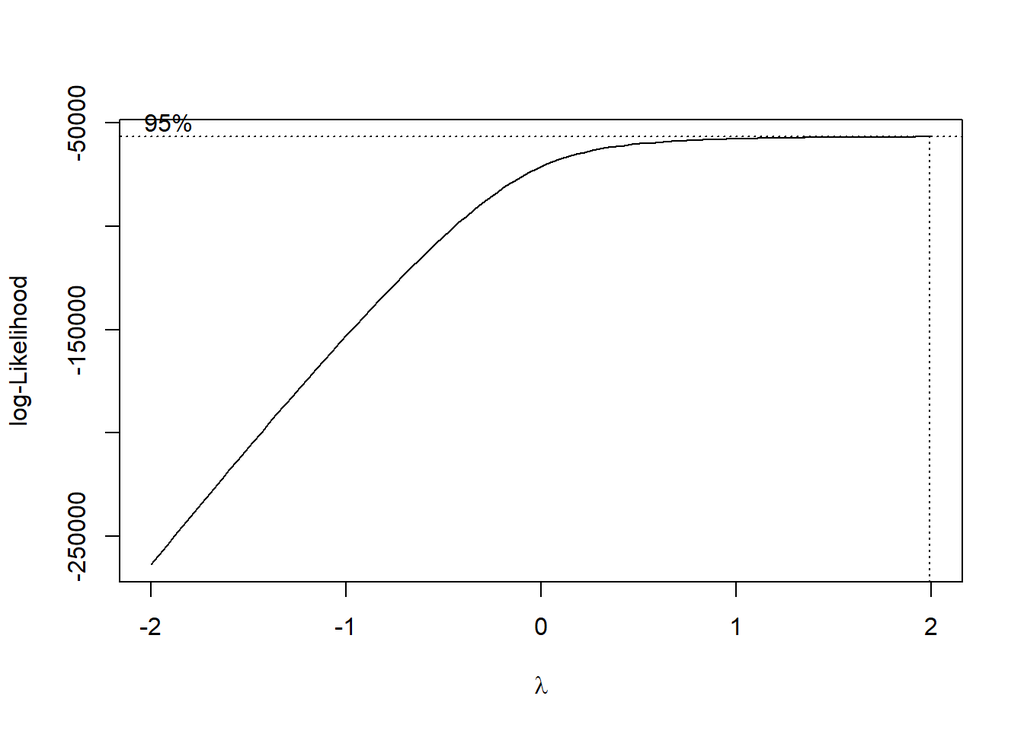

```r
library(MASS)
library(car)

# Ajusted Box-Cox
model_for_bc <- update(model1, Condition + 0.1 ~ .)

# Find the best Lambda
bc <- boxcox(model_for_bc, plotit = TRUE)
```

```r
lambda <- bc$x[which.max(bc$y)]
print(paste("Best Lambda:", round(lambda, 2)))
```

```
[1] "Best Lambda: 2"
```

Since the response variable Condition contains zero values and the Box-Cox transformation involves logarithmic operations (which are undefined for zero), a small constant shift parameter of $0.1$ was added to the response ($Y + 0.1$). To address the severe heteroscedasticity detected in the residual analysis, we performed a Box-Cox transformation to identify an appropriate power transformation for the response variable. The resulting profile log-likelihood plot indicated an optimal $\lambda$ value of approximately 2, which suggests that a quadratic transformation is necessary to stabilize the variance. Consequently, we will proceed by defining a new model using the square of the bridge condition ($Y^2$) as the response variable to improve adherence to the linear regression assumptions.

## 2.5 Transformed Model

```r
mod_transf <- lm(I((Condition + 0.1)^2) ~ . - Structure_id + Year:Material, data = db_train)

summary(mod_transf)
```

```
Call:
lm(formula = I((Condition + 0.1)^2) ~ . - Structure_id + Year:Material,
    data = db_train)

Residuals:
    Min      1Q  Median      3Q     Max
-409.59  -35.42    0.17   34.67  309.65

Coefficients:
                       Estimate Std. Error t value Pr(>|t|)
(Intercept)          -4.208e+03  6.125e+01 -68.698  < 2e-16 ***
UrbanUrban           -3.289e+00  8.736e-01  -3.765 0.000167 ***
Year                  2.341e+00  3.068e-02  76.299  < 2e-16 ***
Lanes_on             -1.638e+00  5.766e-01  -2.842 0.004492 **
AverageDaily         -7.750e-05  2.000e-05  -3.875 0.000107 ***
HistoricPossible      1.328e+01  1.415e+00   9.386  < 2e-16 ***
HistoricRegister      1.622e+01  3.871e+00   4.189 2.82e-05 ***
HistoricUnknown       7.417e+01  9.304e+00   7.972 1.63e-15 ***
MaterialMasonry       2.125e+03  1.610e+03   1.320 0.187003
MaterialOther        -5.098e+02  7.437e+02  -0.685 0.493072
MaterialSteel         1.485e+03  7.679e+01  19.340  < 2e-16 ***
MaterialTimber        1.808e+01  3.658e+02   0.049 0.960585
Spans                -1.495e+00  1.001e-01 -14.933  < 2e-16 ***
Length                1.324e-02  2.726e-03   4.856 1.21e-06 ***
Width                 5.708e-01  1.104e-01   5.172 2.34e-07 ***
Trucks_percent        3.886e-02  4.047e-02   0.960 0.336932
Year:MaterialMasonry -1.055e+00  8.323e-01  -1.268 0.204786
Year:MaterialOther    2.532e-01  3.734e-01   0.678 0.497660
Year:MaterialSteel   -7.790e-01  3.882e-02 -20.066  < 2e-16 ***
Year:MaterialTimber  -6.669e-02  1.844e-01  -0.362 0.717662
---
Signif. codes:  0 '***' 0.001 '**' 0.01 '*' 0.05 '.' 0.1 ' ' 1

Residual standard error: 57.17 on 23888 degrees of freedom
Multiple R-squared:  0.4857,    Adjusted R-squared:  0.4853
F-statistic:  1187 on 19 and 23888 DF,  p-value: < 2.2e-16
```

The transformation also clarified the contribution of specific predictors. The interaction between `Year` and `MaterialSteel` remains highly significant, confirming that steel structures age differently than concrete ones. However, the variable `Trucks_percent` lost its statistical significance ($p = 0.33$) in this new scale, and several interaction terms (such as those for Masonry and Timber) proved to be non-informative. These findings suggest that the current model contains unnecessary complexity, justifying the application of an automatic stepwise selection algorithm to remove redundant variables and optimize predictive performance.

## 2.6 Homocedasticity test

```r
bptest(mod_transf)
```

```
    studentized Breusch-Pagan test

data:  mod_transf
BP = 445.82, df = 19, p-value < 2.2e-16
```

The Breusch-Pagan test still indicates the presence of heteroscedasticity ($p < 2.2e-16$), the slight reduction in the test statistic suggests a marginal improvement in variance stabilization. Given the large sample size, strictly constant variance is difficult to achieve, and this quadratic model offers a superior fit to the data compared to the linear baseline.

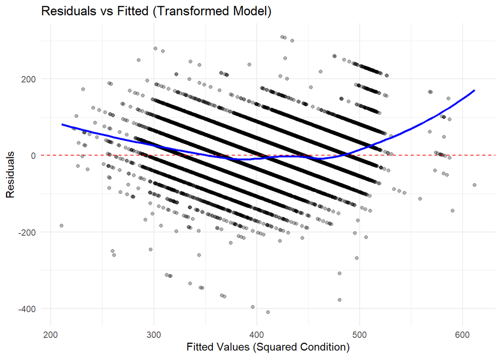

```r
ggplot(data.frame(fitted = fitted(mod_transf), residuals = residuals(mod_transf)),
       aes(x = fitted, y = residuals)) +
  geom_point(alpha = 0.3) +
  geom_hline(yintercept = 0, linetype = "dashed", color = "red") +
  geom_smooth(method = "loess", se = FALSE, color = "blue") +
  labs(x = "Fitted Values (Squared Condition)",
       y = "Residuals",
       title = "Residuals vs Fitted (Transformed Model)") +
  theme_minimal()
```

To further validate the quadratic model, we analyzed the residual patterns using advanced visualization techniques. The ggplot of residuals versus fitted values shows a cloud of points centered around zero. However, the Loess smoothing line (blue) exhibits a slight curvature, particularly at the extremes of the fitted values. This suggests that while the quadratic transformation significantly improved the model fit compared to the base linear model, some minor non-linear patterns remain uncaptured.

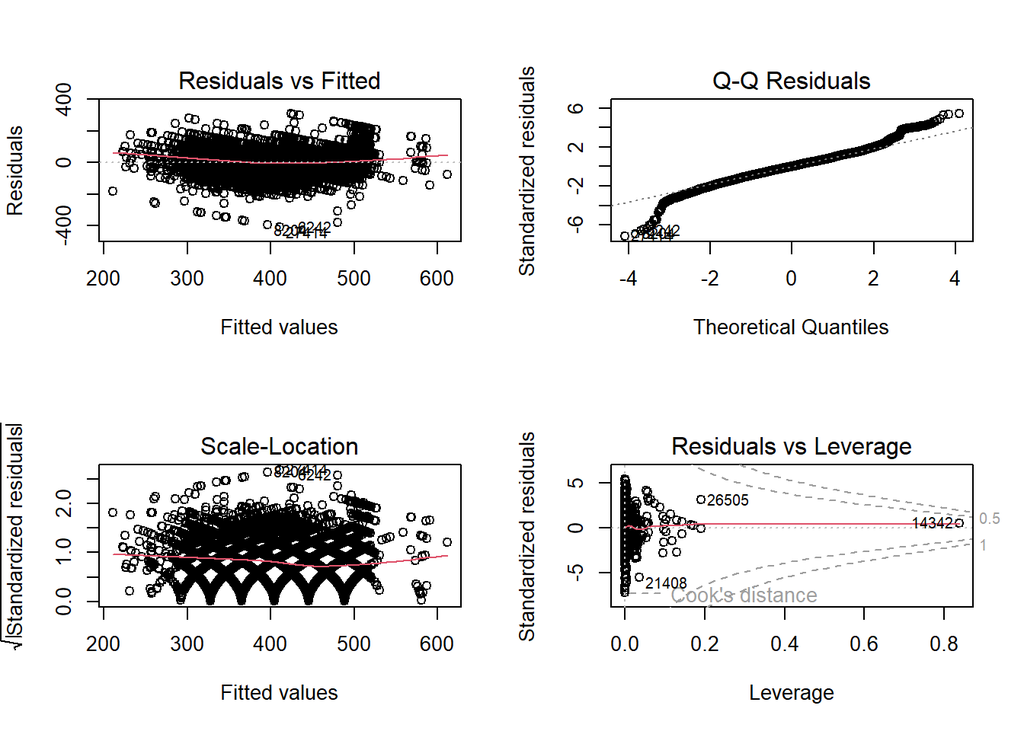

```r
par(mfrow = c(2, 2))
plot(mod_transf)
```

```r
par(mfrow = c(1, 1))
```

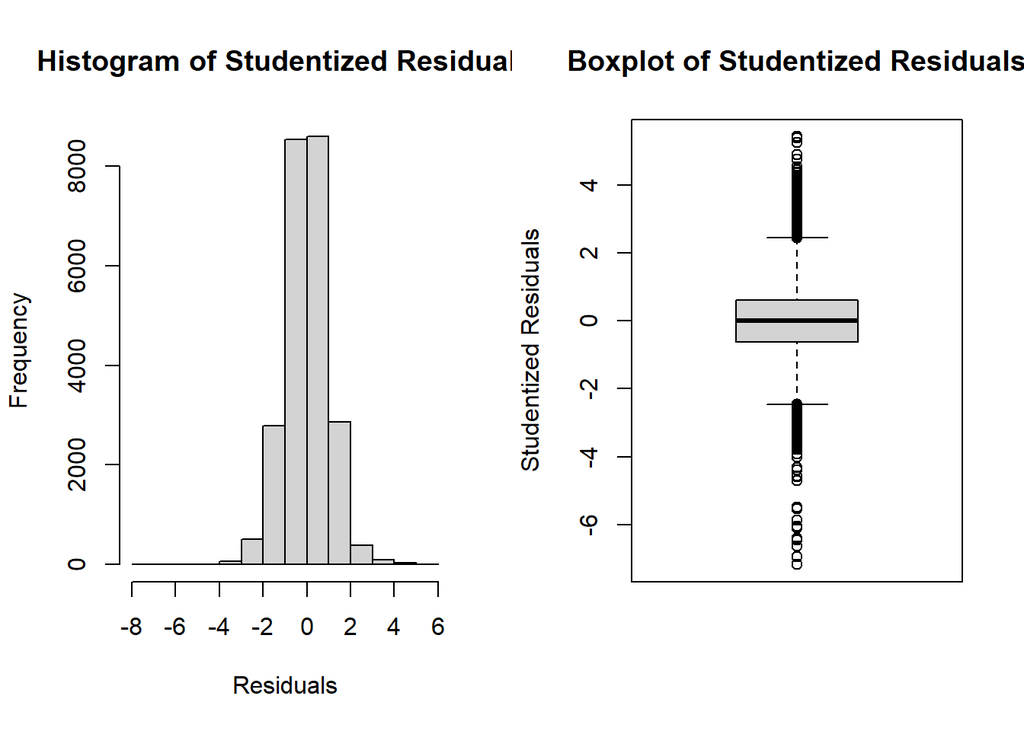

```r
par(mfrow=c(1,2))
res <- rstudent(mod_transf)

hist(res, main = "Histogram of Studentized Residuals",
     xlab = "Residuals")

boxplot(res, main = "Boxplot of Studentized Residuals", ylab = "Studentized Residuals")
```

```r
par(mfrow=c(1,1))
```

Additionally, the analysis of studentized residuals reveals a histogram that approximates a normal distribution, albeit with heavy tails as highlighted by the outliers in the boxplot. Despite these minor deviations, the model’s low RMSE on the test set confirms that these issues do not significantly compromise its predictive power.

```r
ppcc::ppccTest(rstudent(model1), qfn = "qnorm") # Filliben test
```

```
    Probability Plot Correlation Coefficient Test

data:  rstudent(model1)
ppcc = 0.97341, n = 23908, p-value < 2.2e-16
alternative hypothesis: rstudent(model1) differs from a Normal distribution
```

### 2.6.1 Automatic model search:

```r
mod_step <- step(mod_transf, direction = "both", trace = 0)
summary(mod_step)
```

```
Call:
lm(formula = I((Condition + 0.1)^2) ~ Urban + Year + Lanes_on +
    AverageDaily + Historic + Material + Spans + Length + Width +
    Year:Material, data = db_train)

Residuals:
    Min      1Q  Median      3Q     Max
-410.12  -35.43    0.18   34.63  309.91

Coefficients:
                       Estimate Std. Error t value Pr(>|t|)
(Intercept)          -4.207e+03  6.124e+01 -68.693  < 2e-16 ***
UrbanUrban           -3.469e+00  8.533e-01  -4.065 4.82e-05 ***
Year                  2.341e+00  3.068e-02  76.296  < 2e-16 ***
Lanes_on             -1.754e+00  5.639e-01  -3.110 0.001873 **
AverageDaily         -7.708e-05  2.000e-05  -3.855 0.000116 ***
HistoricPossible      1.348e+01  1.399e+00   9.638  < 2e-16 ***
HistoricRegister      1.626e+01  3.871e+00   4.200 2.68e-05 ***
HistoricUnknown       7.411e+01  9.304e+00   7.966 1.72e-15 ***
MaterialMasonry       2.121e+03  1.610e+03   1.317 0.187743
MaterialOther        -5.183e+02  7.436e+02  -0.697 0.485852
MaterialSteel         1.489e+03  7.670e+01  19.414  < 2e-16 ***
MaterialTimber        8.026e+00  3.656e+02   0.022 0.982488
Spans                -1.492e+00  1.000e-01 -14.911  < 2e-16 ***
Length                1.337e-02  2.723e-03   4.910 9.19e-07 ***
Width                 5.991e-01  1.064e-01   5.633 1.79e-08 ***
Year:MaterialMasonry -1.054e+00  8.323e-01  -1.266 0.205506
Year:MaterialOther    2.574e-01  3.734e-01   0.689 0.490528
Year:MaterialSteel   -7.810e-01  3.877e-02 -20.145  < 2e-16 ***
Year:MaterialTimber  -6.177e-02  1.844e-01  -0.335 0.737601
---
Signif. codes:  0 '***' 0.001 '**' 0.01 '*' 0.05 '.' 0.1 ' ' 1

Residual standard error: 57.17 on 23889 degrees of freedom
Multiple R-squared:  0.4856,    Adjusted R-squared:  0.4853
F-statistic:  1253 on 18 and 23889 DF,  p-value: < 2.2e-16
```

```r
print(paste("R2 transformed model:", summary(mod_transf)$adj.r.squared))
```

```
[1] "R2 transformed model: 0.485250227615901"
```

```r
print(paste("R2 stepwise model:", summary(mod_step)$adj.r.squared))
```

```
[1] "R2 stepwise model: 0.485251906011248"
```

The application of the stepwise regression algorithm based on the AIC criterion identified `Trucks_percent` as a non-informative predictor, suggesting its removal from the model. This simplification resulted in a more parsimonious model that retains the exact same explanatory power as the full version, with the Adjusted $R^2$ remaining stable at approximately 0.485. Furthermore, the ANOVA comparison between the full transformed model and the reduced model confirms that the exclusion of this variable does not result in a statistically significant loss of fit ($p > 0.05$), thereby justifying the adoption of the simpler model for final testing and predictions.

## 2.8 Model Validation

```r
anova(mod_step, mod_transf)
```

|  | Res.Df | RSS | Df | Sum of Sq | F | Pr(>F) |
| --- | --- | --- | --- | --- | --- | --- |
| 1 | 23889 | 78089197 | NA | NA | NA | NA |
| 2 | 23888 | 78086182 | 1 | 3014.227 | 0.9221074 | 0.336932 |

The Analysis of Variance (ANOVA) performed to compare the full transformed model with the reduced model obtained via stepwise selection yielded a p-value of 0.3369. This result indicates that there is no statistically significant difference between the two models, confirming that the variable `Trucks_percent` does not contribute meaningfully to the prediction of the bridge condition. Consequently, we fail to reject the null hypothesis and select the reduced model as our final candidate, as it offers a more parsimonious solution with equivalent explanatory power (Adjusted $R^2 \approx 0.485$) while fulfilling the principle of Occam’s razor.

## 2.9 Predictive Performance

```r
#predict test results (db_test)
pred_sq_test <- predict(mod_step, newdata = db_test)

pred_test_real <- sqrt(pmax(0, pred_sq_test)) - 0.1

#RMSE
actuals <- db_test$Condition
rmse_score <- sqrt(mean((actuals - pred_test_real)^2))

print(paste("RMSE:", round(rmse_score, 4)))
```

```
[1] "RMSE: 1.4595"
```

To assess the model’s generalization capability, we evaluated its performance on the held-out test set (20% of the data), achieving a Root Mean Squared Error (RMSE) of 1.4595. This result demonstrates strong predictive accuracy relative to the Condition scale (0–27) and confirms that the quadratic model with interactions captures the underlying structural patterns without overfitting. Consequently, this validated model was applied to the unlabelled predict.csv dataset, reversing the Box-Cox transformation to generate the final predictions presented below.

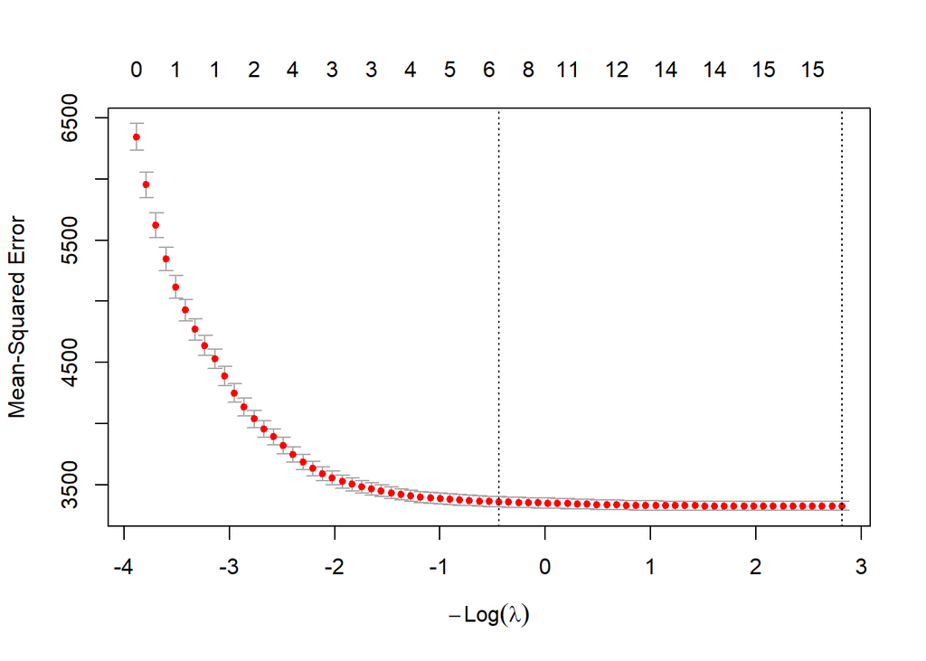

```r
library(glmnet)
set.seed(3185)
X_train <- model.matrix(I((Condition + 0.1)^2) ~ . - Structure_id + Year:Material, data = db_train)[, -1]
Y_train <- (db_train$Condition + 0.1)^2

X_test <- model.matrix(Condition ~ . - Structure_id + Year:Material, data = db_test)[, -1]

cv_lasso <- cv.glmnet(X_train, Y_train, alpha = 1)


plot(cv_lasso)
```

```r
best_lambda <- cv_lasso$lambda.1se

print(paste("Best Lambda:", best_lambda))
```

```
[1] "Best Lambda: 1.55174314281549"
```

```r
pred_lasso_sq <- predict(cv_lasso, newx = X_test, s = best_lambda)
pred_lasso_real <- sqrt(pmax(0, pred_lasso_sq)) - 0.1


rmse_lasso <- sqrt(mean((db_test$Condition - pred_lasso_real)^2))

print(paste("RMSPE Stepwise:", round(rmse_score, 4)))
```

```
[1] "RMSPE Stepwise: 1.4595"
```

```r
print(paste("RMSPE LASSO:", round(rmse_lasso, 4)))
```

```
[1] "RMSPE LASSO: 1.4752"
```

```r
predict_data <- read.csv("predict.csv")

# Predictions
pred_sq_final <- predict(mod_step, newdata = predict_data)
pred_final_real <- sqrt(pmax(0, pred_sq_final)) - 0.1


predictions <- data.frame(
  Structure_id = predict_data$Structure_id,
  Condition = pred_final_real
)

head(predictions)
```

|  | Structure_id | Condition |
| --- | --- | --- |
| 1 | 090980AA0158001 | 21.70081 |
| 2 | 150150001701045 | 18.10707 |
| 3 | 131580AA0146001 | 18.91432 |
| 4 | 060690000407036 | 19.86515 |
| 5 | 111140AA0302004 | 19.91420 |
| 6 | 161780010201130 | 22.03797 |

# 3 Model evaluation

Even after the model transformation, our diagnostics showed that the variance structure is incompatible with Gaussian assumptions. There are significant departures from normality in the Q-Q residuals test, suggesting the Gaussian error assumption is inappropriate. The Breutsch-Pagan test strongly rejects constant variance even after transformation of the response. In contrast, the Residuals vs Fitted plot indicates that the mean structure is broadly adequate, implying that the primary source of misspecification lies in the variance model rather than the linear predictor. Given the evident mean–variance dependence and the discrete, non-Gaussian nature of the response, a generalized linear model with an appropriate variance function is therefore more suitable than a homoskedastic Gaussian linear model.